# Analysis code for valuing diversity intervention experiment

# Setup

**Source**

```r
pacman::p_load(tidyverse, magrittr, lme4, lmerTest)
pacman::p_install_version("emmeans", "1.4.8")
pacman::p_load_gh("lukaswallrich/timesaveR")

#Contact Lukas Wallrich (l.wallrich@gold.ac.uk | lukas.wallrich@gmail.com) to access the data
df <- read_rds('data_with_conditions.RDS')
```

**Source**

```r
cohen_d <- function(df, DV, group, na.rm = TRUE) {
  desc <- df %>%
    rename(group = {{ group }}) %>%
    group_by(group) %>%
    summarise(M = mean({{ DV }}, na.rm = na.rm), var = var({{ DV }}, na.rm = na.rm), N = n()) %>%
    arrange(group)
  out <- tibble::tribble(
    ~pair, ~d
  )
  for (i in 1:(nrow(desc) - 1)) {
    for (j in (i + 1):nrow(desc)) {
      pair <- paste(desc$group[i], "&", desc$group[j])
      sd_pooled <- sqrt(((desc$N[i] - 1) * desc$var[i] + (desc$N[j] - 1) * desc$var[j]) / (desc$N[j] + desc$N[i] - 2))
      d <- (desc$M[i] - desc$M[j]) / sd_pooled
      out %<>% rbind(tibble::tibble(pair = pair, d = d))
    }
  }
  return(out)
}

hedges_g <- function(df, DV, group, na.rm = TRUE, ci = .95) {
  df %<>% select({{ DV }}, {{ group }}) %>% rename(group = {{ group }}, DV = {{ DV }})
  if (na.rm) df %<>% tidyr::drop_na()
  groups <- df$group %>%
    unique() %>%
    sort()
  out <- tibble::tibble()
  for (i in 1:(length(groups) - 1)) {
    for (j in (i + 1):length(groups)) {
      pair <- paste(groups[i], "&", groups[j])
      g <- gethedgesg(df$DV[df$group == groups[j]], df$DV[df$group == groups[i]], coverage = ci)
      g$pair <- pair
      out %<>% rbind(g)
    }
  }
  out %>% dplyr::select(pair, dplyr::everything())
}

gethedgesg <- function(x1, x2, design = "between", coverage = 0.95) {
  # http://www.tqmp.org/RegularArticles/vol14-4/p242/
  # mandatory arguments are x1 and x2, both a vector of data
  require(psych) # for the function harmonic.mean.
  # get basic descriptive statistics
  ns <- c(length(x1), length(x2))
  mns <- c(mean(x1), mean(x2))
  sds <- c(sd(x1), sd(x2))
  # get pairwise statistics
  ntilde <- harmonic.mean(ns)
  dmn <- mns[2] - mns[1]
  sign_diff <- 1
  if (dmn < 0) sign_diff <- -1
  dmn <- abs(dmn)
  sdp <- sqrt((ns[1] - 1) * sds[1]^2 + (ns[2] - 1) * sds[2]^2) / sqrt(ns[1] + ns[2] - 2)
  # compute biased Cohen’s d (equation 1)
  cohend <- dmn / sdp
  # compute unbiased Hedges’ g ( equations 2a and 3)
  eta <- ns[1] + ns[2] - 2
  J <- exp(lgamma(eta / 2) - (log(sqrt(eta / 2)) + lgamma((eta - 1) / 2)))
  hedgesg <- cohend * J
  # compute noncentrality parameter (equation 5a or 5b depending on the design)
  lambda <- if (design == "between") {
    hedgesg * sqrt(ntilde / 2)
  } else {
    r <- cor(x1, x2)
    hedgesg * sqrt(ntilde / (2 * (1 - r)))
  }
  # confidence interval of the hedges g ( equations 6 and 7)
  tlow <- qt(1 / 2 - coverage / 2, df = eta, ncp = lambda)
  thig <- qt(1 / 2 + coverage / 2, df = eta, ncp = lambda)
  dlow <- tlow / lambda * hedgesg
  dhig <- thig / lambda * hedgesg
  # all done! display the results
  (tibble(g = hedgesg, ci.lower = dlow, ci.upper = dhig) * sign_diff) %>% tibble::as_tibble()
  # cat("Hedges’g = ", hedgesg, "\n", coverage*100, "% CI = [", dlow, dhig, "]\n")
}

report_anova <- function(x, to_clip = interactive()) {
  out <- x %>%
    data.frame() %>%
    rownames_to_column() %>%
    mutate(report = glue::glue("{rowname}: F({round(DenDF)}, {NumDF}) = {round_(F.value)}, p {fmt_p(Pr..F.)}"))
  if (to_clip) clipr::write_clip(out$report)
  out
}

m_sd <- function(x) {
  paste0(sprintf("%0.2f", mean(x, na.rm = T)), " (", sprintf("%0.2f", sd(x, na.rm = T)), ")")
}
```

# Facilitator feedback - implementation check

**Source**

```r
#Contact Lukas Wallrich (l.wallrich@gold.ac.uk) to access the data
facilitators <- read_csv('MentorSurvey_diversity.csv') %>% as.data.frame()
```

**Message**

**Source**

```r
facilitators <- facilitators %>% mutate(Activity = factor(Activity), Close = factor(Close), Engaged = case_when(
  Engaged == "Very disengaged" ~ 1,
  Engaged == "Rather disengaged" ~ 2,
  Engaged == "Rather engaged" ~ 3,
  Engaged == "Very engaged" ~ 4,
  TRUE ~ NA_real_))


table(facilitators$Close) %>% prop.table() %>% `*`(100) %>% round(1)
```

**Output**

```
##
##   I had to make some bigger adjustments    I had to make some minor adjustments
##                                     2.3                                    27.8
## I had to run a rather different session           I ran it exactly as described
##                                     0.8                                    69.1
```

**Source**

```r
table(facilitators$Close, facilitators$Activity) %>% prop.table(margin = 2) %>% `*`(100) %>% round(1)
```

**Output**

```
##
##                                              A    B    C
##   I had to make some bigger adjustments    1.7  2.7  2.4
##   I had to make some minor adjustments    35.3 20.0 27.6
##   I had to run a rather different session  0.9  0.9  0.8
##   I ran it exactly as described           62.1 76.4 69.3
```

**Source**

```r
chisq.test(facilitators$Close, facilitators$Activity)
```

**Warning**

```
## Warning in chisq.test(facilitators$Close, facilitators$Activity): Chi-squared
## approximation may be incorrect
```

**Output**

```
##
##  Pearson's Chi-squared test
##
## data:  facilitators$Close and facilitators$Activity
## X-squared = 6.7308, df = 6, p-value = 0.3465
```

**Source**

```r
facilitators %>% group_by(Activity) %>% summarise(mean(Engaged, na.rm = TRUE))
```

**Output**

```
## # A tibble: 4 x 2
##   Activity `mean(Engaged, na.rm = TRUE)`
##   <fct>                            <dbl>
## 1 A                                 3.16
## 2 B                                 3.08
## 3 C                                 3.23
## 4 <NA>                            NaN
```

**Source**

```r
lm(Engaged ~ Activity, facilitators) %>% summary()
```

**Output**

```
##
## Call:
## lm(formula = Engaged ~ Activity, data = facilitators)
##
## Residuals:
##      Min       1Q   Median       3Q      Max
## -2.23016 -0.23016 -0.08182  0.76984  0.91818
##
## Coefficients:
##             Estimate Std. Error t value Pr(>|t|)
## (Intercept)  3.15517    0.06919  45.603   <2e-16 ***
## ActivityB   -0.07335    0.09917  -0.740    0.460
## ActivityC    0.07499    0.09589   0.782    0.435
## ---
## Signif. codes:  0 '***' 0.001 '**' 0.01 '*' 0.05 '.' 0.1 ' ' 1
##
## Residual standard error: 0.7452 on 349 degrees of freedom
##   (209 observations deleted due to missingness)
## Multiple R-squared:  0.006638,   Adjusted R-squared:  0.0009452
## F-statistic: 1.166 on 2 and 349 DF,  p-value: 0.3128
```

**Source**

```r
m_sd(facilitators$Engaged)
```

**Output**

```
## [1] "3.16 (0.75)"
```

# Data prep and descriptive statistics

**Source**

```r
df %<>% mutate(ethnicity = paste(`INFO:E-END`, `INFO:E-START`),
  ethn = case_when(
    str_detect(ethnicity, "White and") ~ "Mixed",
    str_detect(ethnicity, "Mixed") ~ "Mixed",
    str_detect(ethnicity, "White") |
    str_detect(ethnicity, "Irish") ~ "White",
    str_detect(ethnicity, "Black|Asian|Roma|Pakistani|Chinese|Bangladeshi|Indian|Arab|other") ~ "ME",
    TRUE ~ NA_character_))

#Not classified
df %>% filter(is.na(ethn)) %>% count(ethnicity, sort = TRUE)
```

**Output**

```
##                             ethnicity    n
## 1                               NA NA 1651
## 2                              NA N/A  317
## 3                              N/A NA  163
## 4                             N/A N/A  100
## 5                NA Prefer not to say   16
## 6                Prefer not to say NA    5
## 7 Prefer not to say Prefer not to say    1
```

**Source**

```r
#Only TCN delivered cohorts participated in experiment
df <- df %>% filter(Delivery == "TCN")
#Small number of cohorts could not be matched to activity assignments due to name changes - thus not known which activity they experienced
df <- df %>% filter(!is.na(Activity1))

#A: getting to know each other
#B: diversity in society
#C: differences in team

  df$Activity1 %<>% relevel(ref="A")

  df$Activity1 %<>% fct_recode(control = "A", society = "B", team = "C")

#Number of responses (any completion status) to end-of-programme survey
sum(df$resp_end>0)
```

**Output**

```
## [1] 1196
```

**Source**

```r
df <- df %>% filter(resp_end > 0)

#Number of cohorts
df$wave %>% unique() %>% length()
```

**Output**

```
## [1] 187
```

**Source**

```r
#Measures:
#### VALUING DIVERSITY
## div society better:
#df$`Q21-END-E` - happy to live in diverse country
#df$`Q22-END-E` - cultural diversity good
## div teams better:
#Q12-END - prefer working in diverse teams
#Q8-END - diverse teams are better
## Comfort talking about differences
#Q18.1-END - comfortable to openly discuss differences in team
#Q17.2-END - important to openly discuss differences in team

#### CONTACT
#Q11-END-E: important to get to know people from other ethnic backgrounds
#Q13.2-END-E: would like more contact with Black British
#Q13.1-END-E: would like more contact with White British
#Q14.2-END-E: will actively approach Black British
#Q14.1-END-E: will actively approach White British
#Q20.2-END-E: only one of your ethnicity in new group - how feel?
#Q41-END: how often discuss commonalities
#Q42-END: how often discuss differences
#Q44-END: how positive/negative contact with participants who are "quite different"

df %<>% rename(pref_div_teams = `Q12-END`,
               div_teams_better = `Q8-END`,
               comf_discussing = `Q18.1-END`,
               imp_discussing = `Q17.2-END`,
               imp_challenging = `Q17.1-END`,
               cont_quality = `Q44-END`,
               freq_discuss_differences = `Q42-END`)


df %$% cor.test(pref_div_teams, div_teams_better)
```

**Output**

```
##
##  Pearson's product-moment correlation
##
## data:  pref_div_teams and div_teams_better
## t = 11.73, df = 406, p-value < 2.2e-16
## alternative hypothesis: true correlation is not equal to 0
## 95 percent confidence interval:
##  0.4268673 0.5722368
## sample estimates:
##       cor
## 0.5031022
```

**Source**

```r
df %$% cor.test(`Q21-END-E`, `Q22-END-E`) #Valuing in society
```

**Output**

```
##
##  Pearson's product-moment correlation
##
## data:  Q21-END-E and Q22-END-E
## t = 12.508, df = 243, p-value < 2.2e-16
## alternative hypothesis: true correlation is not equal to 0
## 95 percent confidence interval:
##  0.5430918 0.6965218
## sample estimates:
##       cor
## 0.6258239
```

**Source**

```r
comf_lookup <- c(1:5)
names(comf_lookup) <- c("Not at all comfortable", "A little comfortable", "Somewhat comfortable", "Quite comfortable", "Very comfortable")
imp_lookup <- c(1:5)
names(imp_lookup) <- c("Not at all important", "A little important", "Somewhat important", "Quite important", "Very important")

df$comf_discussing <- comf_lookup[df$comf_discussing %>% as.character()]
df$imp_discussing <- imp_lookup[df$imp_discussing %>% as.character()]
df$imp_challenging <- imp_lookup[df$imp_challenging %>% as.character()]

df$val_div_society <- make_scale(df, c("Q21-END-E", "Q22-END-E"), "Valuing diversity in society")
```

**Output**

```
##
## Descriptives for Valuing diversity in society scale:
## Mean: 3.004  SD: 1.142
## spearman_brown: 0.77
```

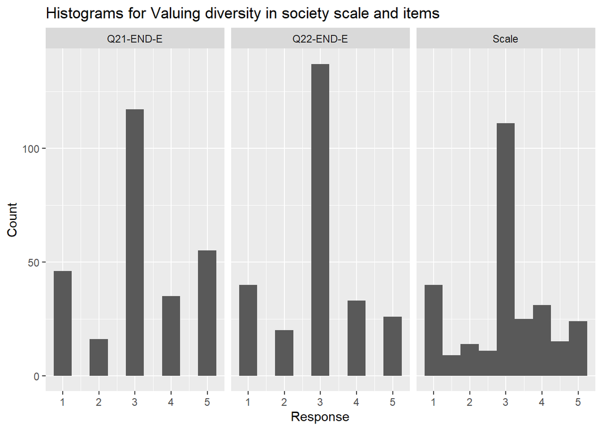

**Source**

```r
df$val_div_teams <- make_scale(df, c("pref_div_teams", "div_teams_better"), "Valuing diversity in teams")
```

**Output**

```
##
## Descriptives for Valuing diversity in teams scale:
## Mean: 2.849  SD: 1.017
## spearman_brown: 0.67
```

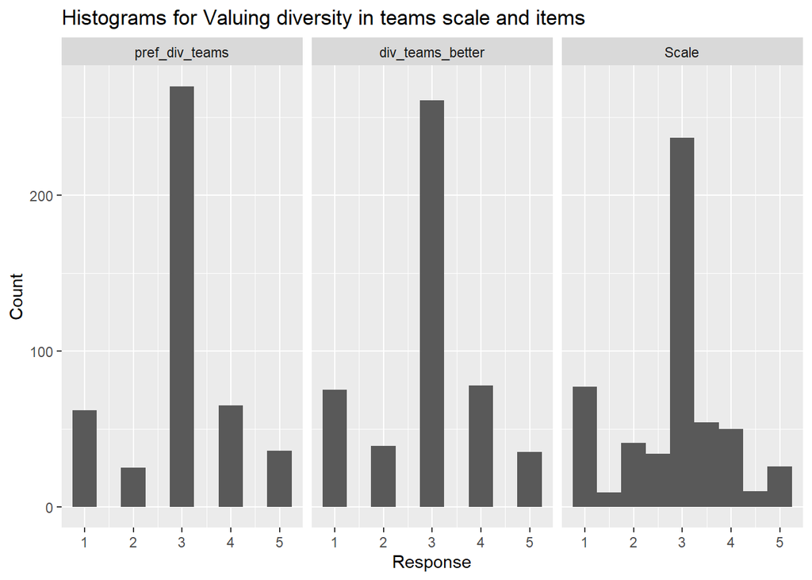

**Source**

```r
df$address_diversity <- make_scale(df, c("comf_discussing", "imp_discussing"), "Addressing diversity in team settings")
```

**Output**

```
##
## Descriptives for Addressing diversity in team settings scale:
## Mean: 3.725  SD: 0.869
## spearman_brown: 0.57
```

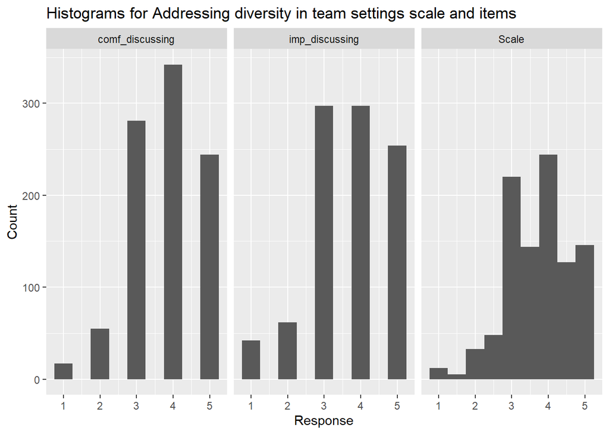

**Source**

```r
cont_quality_lookup <- c(1:5)
names(cont_quality_lookup) <- c("Very negative", "Negative", "Neutral", "Positive", "Very positive")
df$cont_quality <- cont_quality_lookup[df$cont_quality %>% as.character()]

approach_lookup <- c(1:5)
names(approach_lookup) <- c("Strongly disagree", "Disagree", "Neutral", "Agree", "Strongly agree")
df$approach_black <- approach_lookup[df$`Q14.2-END-E` %>% as.character()]
df$approach_white <- approach_lookup[df$`Q14.1-END-E` %>% as.character()]

df$approach <- df %$% coalesce(approach_black, approach_white)

freq_lookup <- c(1:5)
names(freq_lookup) <- c("Never", "Rarely", "Sometimes", "Often", "Very often")
df$freq_discuss_differences  <- freq_lookup[df$freq_discuss_differences %>% as.character()]
```

**Source**

```r
n_resp <- function(x) {
  sum(!is.na(x))
}

df$responded_any <- df %>%
  select(val_div_society, val_div_teams, approach, cont_quality, address_diversity, freq_discuss_differences) %>%
  {
    rowSums(!is.na(.)) > 0
  }


df$responded <- FALSE

df$responded[!is.na(df$val_div_society)|!(is.na(df$val_div_teams))] <- TRUE

table(df$responded, df$Activity1) %>% prop.table(margin = 2)
```

**Output**

```
##
##           control   society      team
##   FALSE 0.4721408 0.5044843 0.4278729
##   TRUE  0.5278592 0.4955157 0.5721271
```

**Source**

```r
sum(df$reponded_any) - sum(df$responded)
```

**Output**

```
## [1] -635
```

**Source**

```r
chisq.test(df$responded, df$Activity1)
```

**Output**

```
##
##  Pearson's Chi-squared test
##
## data:  df$responded and df$Activity1
## X-squared = 5.0463, df = 2, p-value = 0.08021
```

**Source**

```r
chisq.test(df$responded_any, df$Activity1)
```

**Output**

```
##
##  Pearson's Chi-squared test
##
## data:  df$responded_any and df$Activity1
## X-squared = 0.48475, df = 2, p-value = 0.7848
```

**Source**

```r
df %<>% filter(responded_any)

df$Activity1 %>% table()
```

**Output**

```
## .
## control society    team
##     297     392     363
```

**Source**

```r
#Ethnic composition
df$ethn %>% table() %>% addmargins()
```

**Output**

```
## .
##    ME Mixed White   Sum
##   248    37   150   435
```

**Source**

```r
df$`INFO:E-END` %>% table() %>% sort(decr = TRUE) %>% head(10)
```

**Output**

```
## .
##          White British                 Indian Other Asian Background
##                    120                     68                     44
##          Black African              Pakistani Other White Background
##                     38                     26                     25
##            Bangladeshi        Black Caribbean Any other Ethnic Group
##                     18                     18                     14
##        White and Asian
##                     13
```

**Source**

```r
df$ethn %>% table() %>% prop.table()
```

**Output**

```
## .
##         ME      Mixed      White
## 0.57011494 0.08505747 0.34482759
```

**Source**

```r
#Run scale functions again for descriptives
df$val_div_society <- make_scale(df, c("Q21-END-E", "Q22-END-E"), "Valuing diversity in society")
```

**Output**

```
##
## Descriptives for Valuing diversity in society scale:
## Mean: 3.004  SD: 1.142
## spearman_brown: 0.77
```

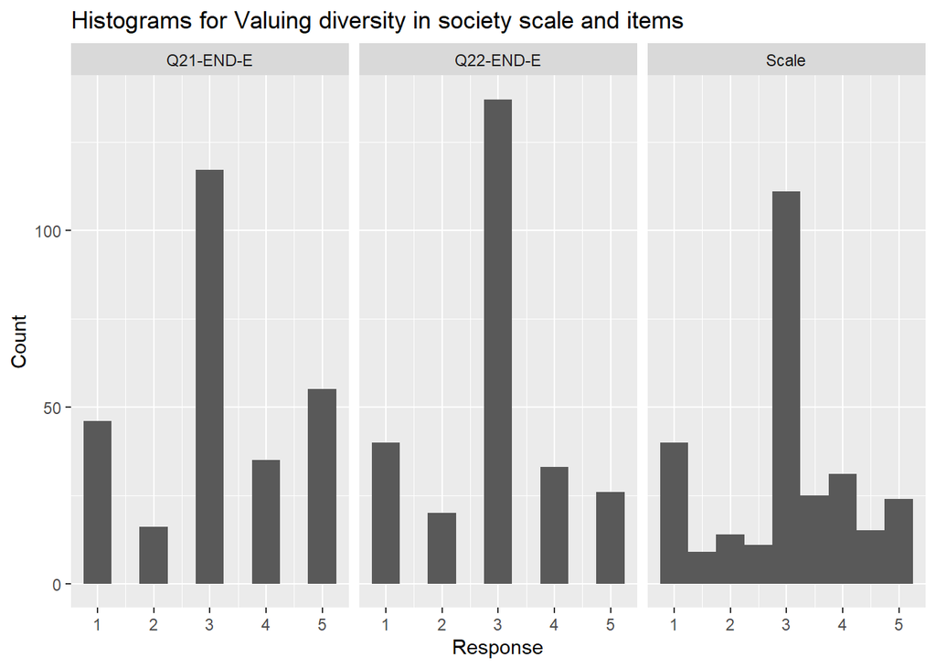

**Source**

```r
df$val_div_teams <- make_scale(df, c("pref_div_teams", "div_teams_better"), "Valuing diversity in teams")
```

**Output**

```
##
## Descriptives for Valuing diversity in teams scale:
## Mean: 2.849  SD: 1.017
## spearman_brown: 0.67
```

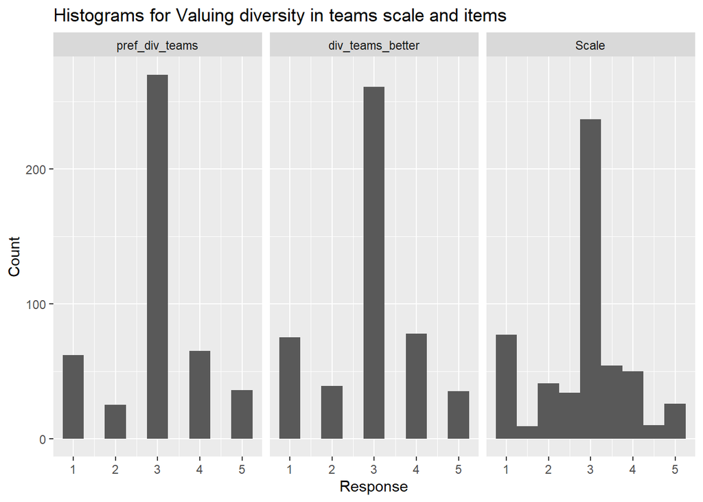

**Source**

```r
df$address_diversity <- make_scale(df, c("comf_discussing", "imp_discussing"), "Addressing diversity in team settings")
```

**Output**

```
##
## Descriptives for Addressing diversity in team settings scale:
## Mean: 3.725  SD: 0.869
## spearman_brown: 0.57
```

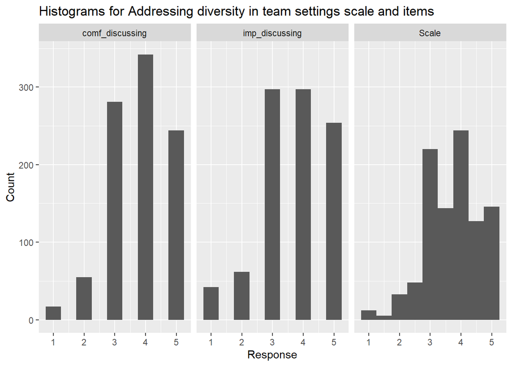

**Source**

```r
df  %>%
 select(val_div_society, val_div_teams, approach, cont_quality, address_diversity, freq_discuss_differences) %>% summarise_all(n_resp)
```

**Output**

```
##   val_div_society val_div_teams approach cont_quality address_diversity
## 1             280           538      384          994               979
##   freq_discuss_differences
## 1                      997
```

**Source**

```r
Ns <- df %>% select(`Valuing diverse teams` = val_div_teams, `Valuing diverse societies` = val_div_society, `Contact quality` = cont_quality, `Frequency of discussing differences` = freq_discuss_differences,  `Interest in contact` = approach, `Commitment to address diversity` = address_diversity) %>% summarise_all(~sum(!is.na(.x))) %>% t() %>% as.numeric() %>% tibble(`*N*` = .)

 df %>% select(`Valuing diverse teams` = val_div_teams, `Valuing diverse societies` = val_div_society, `Contact valence` = cont_quality, `Frequency of discussing differences` = freq_discuss_differences,  `Interest in contact` = approach, `Commitment to address diversity` = address_diversity) %>% cor_matrix() %>% report_cor_table(filename = "cor_table.html", extras = Ns)
```

**Message**

```
## Note that the ordering of the 'extras' argument is not checked - ensure that it matches 'desc' in the correlation matrix.
```

**Source**

```r
# Descriptives - all
 d <- df %>% group_by(Activity1) %>%
        summarise(`*N*` = n(),
                  `Valuing diverse teams` = m_sd(val_div_teams),
                  `Valuing diverse societies` = m_sd(val_div_society),
                  `Contact valence` = m_sd(cont_quality),
                  `Discussing differences` = m_sd(freq_discuss_differences),
                  `Interest in contact` = m_sd(approach),
                  `Address diversity` = m_sd(address_diversity)) %>%
   arrange(match(Activity1, c("team", "society", "control"))) %>% rename(Condition = Activity1)

 d$Condition <- c("1. Diversity in teams", "2. Diversity in society", "3. Control")

d %>% gt::gt() %>% modelsummary:::fmt_labels_md("column") %>% gt_apa_style()
```

Condition

*N*

Valuing diverse teams

Valuing diverse societies

Contact valence

Discussing differences

Interest in contact

Address diversity

1. Diversity in teams

363

2.88 (0.99)

2.98 (1.13)

3.88 (0.75)

3.45 (0.93)

3.37 (0.91)

3.76 (0.86)

2. Diversity in society

392

2.85 (1.05)

3.02 (1.18)

3.79 (0.82)

3.27 (0.90)

3.42 (0.81)

3.68 (0.87)

3. Control

297

2.81 (1.01)

3.02 (1.14)

3.92 (0.75)

3.39 (0.90)

3.40 (0.80)

3.74 (0.88)

**Source**

```r
#By ethn
d <- df %>% filter(ethn %in% c("White", "ME")) %>% group_by(ethn, Activity1) %>%
        summarise(`*N*` = n(),
                  `Valuing diverse teams` = m_sd(val_div_teams),
                  `Valuing diverse societies` = m_sd(val_div_society),
                  `Contact valence` = m_sd(cont_quality),
                                    `Discussing differences` = m_sd(freq_discuss_differences),
                  `Approach intentions` = m_sd(approach),
                  `Commitment to address diversity` = m_sd(address_diversity)) %>%
   arrange(match(Activity1, c("team", "society", "control"))) %>% rename(Condition = Activity1)
```

**Message**

**Source**

```r
 d$Condition <- c("1. Diversity in teams", "1. Diversity in teams", "2. Diversity in society","2. Diversity in society", "3. Control", "3. Control")

d %>% gt::gt() %>% modelsummary:::fmt_labels_md("column") %>% gt_apa_style()
```

| Condition | *N* | Valuing diverse teams | Valuing diverse societies | Contact valence | Discussing differences | Approach intentions | Commitment to address diversity |
| --- | --- | --- | --- | --- | --- | --- | --- |
| ME |  |  |  |  |  |  |  |
| 1. Diversity in teams | 84 | 3.07 (0.93) | 3.08 (1.18) | 3.83 (0.79) | 3.49 (1.06) | 3.34 (0.93) | 3.82 (0.92) |
| 2. Diversity in society | 84 | 3.13 (0.98) | 3.00 (1.02) | 3.75 (0.77) | 3.28 (0.74) | 3.27 (0.72) | 3.59 (0.81) |
| 3. Control | 80 | 2.50 (1.00) | 2.92 (1.14) | 3.89 (0.79) | 3.39 (0.90) | 3.24 (0.71) | 3.75 (0.89) |
| White |  |  |  |  |  |  |  |
| 1. Diversity in teams | 73 | 2.74 (0.93) | 2.82 (0.98) | 3.91 (0.70) | 3.42 (0.88) | 3.41 (0.88) | 3.89 (0.86) |
| 2. Diversity in society | 45 | 2.72 (1.05) | 3.08 (1.37) | 4.09 (0.88) | 3.23 (0.99) | 3.67 (0.87) | 3.98 (0.78) |
| 3. Control | 32 | 2.92 (0.80) | 3.23 (1.21) | 4.13 (0.72) | 3.59 (0.91) | 3.77 (0.82) | 3.80 (0.98) |

# Inferential tests for main effects

Non-significant ones not really interesting based on descriptive statistics - not reported in detail

**Source**

```r
 lmer((val_div_teams) ~ 1 + (1|wave), data=df) %>% ranova()
```

**Output**

```
## ANOVA-like table for random-effects: Single term deletions
##
## Model:
## (val_div_teams) ~ (1 | wave)
##            npar  logLik    AIC    LRT Df Pr(>Chisq)
## <none>        3 -772.03 1550.1
## (1 | wave)    2 -774.16 1552.3 4.2645  1    0.03892 *
## ---
## Signif. codes:  0 '***' 0.001 '**' 0.01 '*' 0.05 '.' 0.1 ' ' 1
```

**Source**

```r
 lmer((val_div_society) ~ 1 + (1|wave), data=df) %>% ranova()
```

**Output**

```
## ANOVA-like table for random-effects: Single term deletions
##
## Model:
## (val_div_society) ~ (1 | wave)
##            npar  logLik    AIC     LRT Df Pr(>Chisq)
## <none>        3 -435.62 877.24
## (1 | wave)    2 -435.80 875.60 0.35713  1     0.5501
```

**Source**

```r
 lmer((cont_quality) ~ 1 + (1|wave), data=df) %>% ranova()
```

**Output**

```
## ANOVA-like table for random-effects: Single term deletions
##
## Model:
## (cont_quality) ~ (1 | wave)
##            npar  logLik    AIC    LRT Df Pr(>Chisq)
## <none>        3 -1160.0 2326.0
## (1 | wave)    2 -1163.7 2331.5 7.5064  1   0.006148 **
## ---
## Signif. codes:  0 '***' 0.001 '**' 0.01 '*' 0.05 '.' 0.1 ' ' 1
```

**Source**

```r
 lmer((approach) ~ 1 + (1|wave), data=df) %>% ranova()
```

**Message**

```
## boundary (singular) fit: see ?isSingular
```

**Output**

```
## ANOVA-like table for random-effects: Single term deletions
##
## Model:
## (approach) ~ (1 | wave)
##            npar  logLik    AIC         LRT Df Pr(>Chisq)
## <none>        3 -483.42 972.85
## (1 | wave)    2 -483.42 970.85 -5.6843e-13  1          1
```

**Source**

```r
 lmer((address_diversity) ~ 1 + (1|wave), data=df) %>% ranova()
```

**Output**

```
## ANOVA-like table for random-effects: Single term deletions
##
## Model:
## (address_diversity) ~ (1 | wave)
##            npar  logLik    AIC   LRT Df Pr(>Chisq)
## <none>        3 -1252.9 2511.8
## (1 | wave)    2 -1254.2 2512.4 2.637  1     0.1044
```

**Source**

```r
 lmer((freq_discuss_differences) ~ 1 + (1|wave), data=df) %>% ranova()
```

**Output**

```
## ANOVA-like table for random-effects: Single term deletions
##
## Model:
## (freq_discuss_differences) ~ (1 | wave)
##            npar  logLik    AIC    LRT Df Pr(>Chisq)
## <none>        3 -1323.0 2652.1
## (1 | wave)    2 -1324.2 2652.4 2.3129  1     0.1283
```

**Source**

```r
 outcomes <- c("val_div_teams", "val_div_society", "cont_quality", "approach", "address_diversity", "freq_discuss_differences")

 reports <- purrr::map_dfr(outcomes, function(outcome) {
   out <- lmer(formula(glue::glue("{outcome} ~ Activity1 + (1|wave)")), data = df) %>% anova(type = 2, ddf = "Ken") %>% report_anova() %>% pull(report)
   tibble(outcome = outcome, report = out)
 })
```

**Message**

```
## boundary (singular) fit: see ?isSingular
```

**Source**

```r
 reports
```

**Output**

```
## # A tibble: 6 x 2
##   outcome                  report
##   <chr>                    <glue>
## 1 val_div_teams            Activity1: F(123, 2) = 0.15, p = .863
## 2 val_div_society          Activity1: F(49, 2) = 0.02, p = .983
## 3 cont_quality             Activity1: F(126, 2) = 1.39, p = .253
## 4 approach                 Activity1: F(48, 2) = 0.16, p = .854
## 5 address_diversity        Activity1: F(117, 2) = 0.36, p = .698
## 6 freq_discuss_differences Activity1: F(118, 2) = 3.15, p = .046
```

**Source**

```r
   lmer((freq_discuss_differences) ~ Activity1 + (1|wave), data=df) %>% emmeans::emmeans(list(pairwise ~ Activity1), adjust = "holm")
```

**Message**

```
## Note: Use 'contrast(regrid(object), ...)' to obtain contrasts of back-transformed estimates
```

**Output**

```
## $`emmeans of Activity1`
##  Activity1 emmean     SE  df lower.CL upper.CL
##  control     3.40 0.0586 128     3.28     3.51
##  society     3.26 0.0519 111     3.16     3.37
##  team        3.44 0.0527 116     3.34     3.55
##
## Degrees-of-freedom method: kenward-roger
## Results are given on the ( (not the response) scale.
## Confidence level used: 0.95
##
## $`pairwise differences of Activity1`
##  1                 estimate     SE  df t.ratio p.value
##  control - society   0.1344 0.0783 120  1.717  0.1771
##  control - team     -0.0447 0.0788 122 -0.567  0.5720
##  society - team     -0.1791 0.0740 114 -2.421  0.0512
##
## Note: contrasts are still on the ( scale
## Degrees-of-freedom method: kenward-roger
## P value adjustment: holm method for 3 tests
```

**Source**

```r
  hedges_g(df, freq_discuss_differences, Activity1) %>% filter(!str_detect(pair, "_NA")) %>% mutate(report = glue::glue("{round_(g)} {fmt_ci(ci.lower, ci.upper)}"))
```

**Message**

**Message**

**Message**

**Output**

```
## # A tibble: 3 x 5
##   pair                    g ci.lower ci.upper report
##   <chr>               <dbl>    <dbl>    <dbl> <glue>
## 1 control & society  0.134   -0.0211    0.291 0.13 [-0.02, 0.29]
## 2 control & team    -0.0675   0.0897   -0.225 -0.07 [0.09, -0.23]
## 3 society & team    -0.201   -0.0540   -0.348 -0.20 [-0.05, -0.35]
```

**Source**

```r
    lmer((freq_discuss_differences) ~ Activity1*ethn + (1|wave), data=df %>% filter(ethn %in% c("White", "ME")))  %>% anova(type = 2, ddf = "Ken") %>% report_anova()
```

**Output**

```
##          rowname    Sum.Sq   Mean.Sq NumDF     DenDF    F.value    Pr..F.
## 1      Activity1 2.6867717 1.3433858     2  50.67083 1.62021465 0.2079379
## 2           ethn 0.0126907 0.0126907     1 353.71604 0.01531105 0.9015932
## 3 Activity1:ethn 1.1763801 0.5881901     2 355.28982 0.70963413 0.4925198
##                                       report
## 1       Activity1: F(51, 2) = 1.62, p = .208
## 2           ethn: F(354, 1) = 0.02, p = .902
## 3 Activity1:ethn: F(355, 2) = 0.71, p = .493
```

# Suppression (mediation model)

**Source**

```r
cor.test(df$freq_discuss_differences, df$val_div_society)
```

**Output**

```
##
##  Pearson's product-moment correlation
##
## data:  df$freq_discuss_differences and df$val_div_society
## t = 3.3087, df = 266, p-value = 0.001067
## alternative hypothesis: true correlation is not equal to 0
## 95 percent confidence interval:
##  0.08092512 0.31122547
## sample estimates:
##       cor
## 0.1988185
```

**Source**

```r
df$soc_act <- ifelse(df$Activity1 == "society", 1, 0)

med_mod <- ("
            val_div_society ~ c*soc_act + b*freq_discuss_differences
            freq_discuss_differences ~ a*soc_act
            indirect := a*b
            direct := c
            total := indirect+direct
            ")

library(lavaan)
```

**Message**

**Message**

**Message**

**Source**

```r
set.seed(300688)
fit <- sem(med_mod, df, se = "bootstrap", test = "bootstrap", bootstrap = 5000, std.ov = TRUE)

plot_data <- tidy(fit, conf.int = TRUE, boot.ci.type = "perc") %>% select(type = label, pvalue = p.value, est = estimate, ci.lower = conf.low, ci.upper = conf.high)

boot_types <- c("norm", "perc", "bca.simple", "basic")

boot_cis <- purrr::map_dfr(boot_types, function(x){
  tidy(fit, conf.int = TRUE, boot.ci.type = x) %>% filter(label == "indirect") %>% transmute(boot_type = x, ci.lower = conf.low, ci.upper = conf.high)
}) #Based on Hayes & Scharkow (2013), only bc and perc are regularly used, and perc is lavaan default - so kept for now, even though some highlight issues with perc, e.g., https://arxiv.org/pdf/1411.5279.pdf

#Hayes & Sharkow (2013) alternatively recommend MC intervals - again similar
mc <- semTools::monteCarloMed("a*b", object = fit)

tibble(boot_type = "monte_carlo", ci.lower = mc$`95% Confidence Interval`[1], ci.upper = mc$`95% Confidence Interval`[1]) %>% bind_rows(boot_cis, .)
```

**Output**

```
## # A tibble: 5 x 3
##   boot_type   ci.lower ci.upper
##   <chr>          <dbl>    <dbl>
## 1 norm          -0.136  0.00874
## 2 perc          -0.151 -0.00852
## 3 bca.simple    -0.161 -0.0119
## 4 basic         -0.120  0.0231
## 5 monte_carlo   -0.151 -0.151
```

**Source**

```r
#Choice might matter because bootstrap results are very skewed - (which is prob usually the case, given how multiplication works?)
 lavInspect(fit, "coef.boot") %>% data.frame() %>% mutate(ind = a*b) %>% ggplot(aes(ind)) + geom_histogram()
```

**Message**

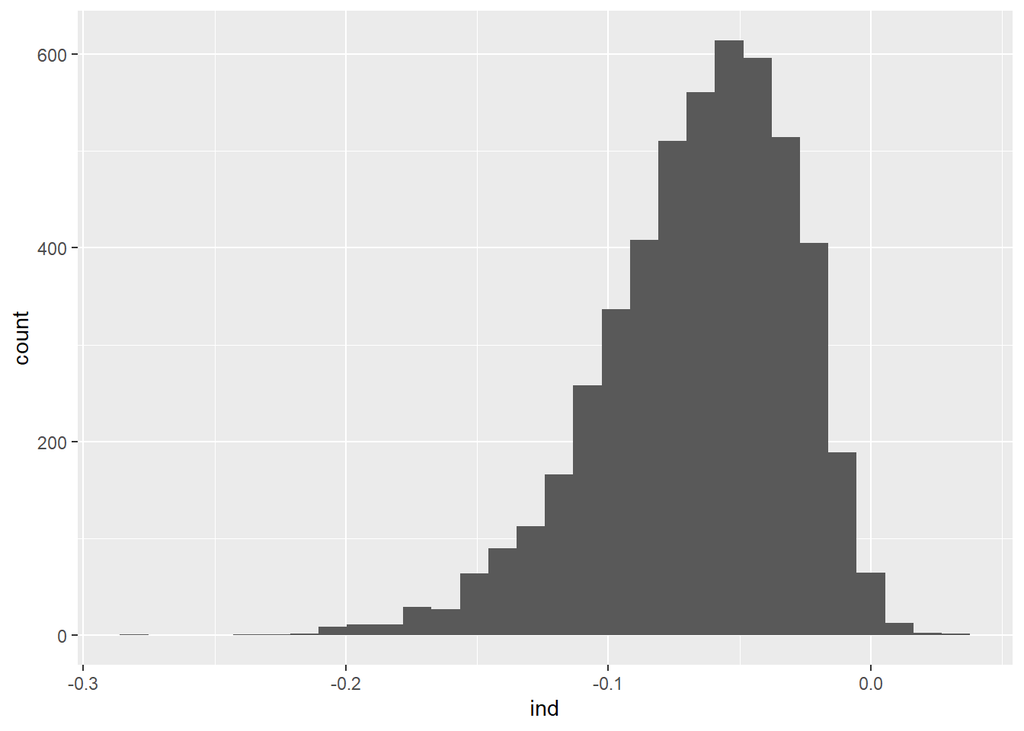

**Source**

```r
med_model <- tibble::tribble(
  ~type, ~mediator,
  "a", "Discussing <br /> differences",
  "b", "Discussing <br /> differences",
  "direct", NA,
  "indirect", "Discussing <br /> differences",
  "total", NA
) %>% left_join(plot_data)
```

**Message**

**Source**

```r
# Run plot command
rNuggets:::plot_mediation(
  IV = "Society-focused <br /> intervention",
  DV = "Valuing diversity <br /> in society", Ms = "Discussing <br /> differences", df = med_model
) %>% extract2(2)
```

**Message**

[interactive chart not shown]

# Interaction with ethnicity

**Source**

```r
df %<>% mutate(ActXethn = paste0(Activity1, "_", ethn))



  lmer((val_div_teams) ~ Activity1*ethn + (1|wave), data=df %>% filter(ethn %in% c("White", "ME"))) %>% anova(type = 3, ddf = "Ken") %>% report_anova()
```

**Output**

```
##          rowname    Sum.Sq   Mean.Sq NumDF     DenDF   F.value     Pr..F.
## 1      Activity1 1.2128540 0.6064270     2  58.75508 0.8800698 0.42014933
## 2           ethn 0.1018111 0.1018111     1 196.63049 0.1477634 0.70109734
## 3 Activity1:ethn 5.4690826 2.7345413     2 195.72500 3.9686517 0.02043937
##                                       report
## 1       Activity1: F(59, 2) = 0.88, p = .420
## 2           ethn: F(197, 1) = 0.15, p = .701
## 3 Activity1:ethn: F(196, 2) = 3.97, p = .020
```

**Source**

```r
  lmer((val_div_society) ~ Activity1*ethn + (1|wave), data=df %>% filter(ethn %in% c("White", "ME"))) %>% anova(type = 3, ddf = "Ken") %>% report_anova()
```

**Output**

```
##          rowname    Sum.Sq   Mean.Sq NumDF     DenDF    F.value    Pr..F.
## 1      Activity1 0.4769516 0.2384758     2  53.89676 0.18705236 0.8299364
## 2           ethn 0.1201671 0.1201671     1 245.35240 0.09428461 0.7590597
## 3 Activity1:ethn 2.6882906 1.3441453     2 244.27483 1.05460552 0.3499103
##                                       report
## 1       Activity1: F(54, 2) = 0.19, p = .830
## 2           ethn: F(245, 1) = 0.09, p = .759
## 3 Activity1:ethn: F(244, 2) = 1.05, p = .350
```

**Source**

```r
  lmer((cont_quality) ~ Activity1*ethn + (1|wave), data=df %>% filter(ethn %in% c("White", "ME"))) %>% anova(type = 3, ddf = "Ken") %>% report_anova()
```

**Message**

```
## boundary (singular) fit: see ?isSingular
```

**Output**

```
##          rowname   Sum.Sq   Mean.Sq NumDF     DenDF   F.value      Pr..F.
## 1      Activity1 1.049196 0.5245978     2  55.37969 0.8661733 0.426176414
## 2           ethn 4.078698 4.0786985     1 354.12857 6.7407843 0.009815787
## 3 Activity1:ethn 1.053753 0.5268765     2 352.89635 0.8707519 0.419534105
##                                       report
## 1       Activity1: F(55, 2) = 0.87, p = .426
## 2           ethn: F(354, 1) = 6.74, p = .010
## 3 Activity1:ethn: F(353, 2) = 0.87, p = .420
```

**Source**

```r
  lmer((freq_discuss_differences) ~ Activity1*ethn + (1|wave), data=df %>% filter(ethn %in% c("White", "ME")))  %>% anova(type = 2, ddf = "Ken") %>% report_anova()
```

**Output**

```
##          rowname    Sum.Sq   Mean.Sq NumDF     DenDF    F.value    Pr..F.
## 1      Activity1 2.6867717 1.3433858     2  50.67083 1.62021465 0.2079379
## 2           ethn 0.0126907 0.0126907     1 353.71604 0.01531105 0.9015932
## 3 Activity1:ethn 1.1763801 0.5881901     2 355.28982 0.70963413 0.4925198
##                                       report
## 1       Activity1: F(51, 2) = 1.62, p = .208
## 2           ethn: F(354, 1) = 0.02, p = .902
## 3 Activity1:ethn: F(355, 2) = 0.71, p = .493
```

**Source**

```r
  lmer((approach) ~ Activity1*ethn + (1|wave), data=df %>% filter(ethn %in% c("White", "ME"))) %>% anova(type = 3, ddf = "Ken") %>% report_anova()
```

**Message**

```
## boundary (singular) fit: see ?isSingular
```

**Output**

```
##          rowname   Sum.Sq   Mean.Sq NumDF     DenDF    F.value       Pr..F.
## 1      Activity1 1.021256 0.5106278     2  54.49287  0.7482295 0.4780021442
## 2           ethn 8.581459 8.5814591     1 325.50790 12.5861269 0.0004457363
## 3 Activity1:ethn 3.238554 1.6192772     2 324.21626  2.3749187 0.0946385601
##                                       report
## 1       Activity1: F(54, 2) = 0.75, p = .478
## 2          ethn: F(326, 1) = 12.59, p < .001
## 3 Activity1:ethn: F(324, 2) = 2.37, p = .095
```

**Source**

```r
  lmer((address_diversity) ~ Activity1*ethn + (1|wave), data=df %>% filter(ethn %in% c("White", "ME"))) %>% anova(type = 3, ddf = "Ken") %>% report_anova()
```

**Output**

```
##          rowname   Sum.Sq   Mean.Sq NumDF     DenDF   F.value     Pr..F.
## 1      Activity1 0.217719 0.1088595     2  63.14739 0.1538498 0.85772117
## 2           ethn 3.508862 3.5088616     1 356.33478 4.9600910 0.02656308
## 3 Activity1:ethn 1.070087 0.5350434     2 356.31136 0.7563275 0.47013911
##                                       report
## 1       Activity1: F(63, 2) = 0.15, p = .858
## 2           ethn: F(356, 1) = 4.96, p = .027
## 3 Activity1:ethn: F(356, 2) = 0.76, p = .470
```

**Source**

```r
  #Post-hoc
  mod_I <- lmer((val_div_teams) ~ Activity1*ethn + (1|wave), data=df %>% filter(ethn %in% c("White", "ME")))
  emmeans::emmeans(mod_I, list(pairwise ~ Activity1 | ethn), adjust = "holm")
```

**Message**

```
## Note: Use 'contrast(regrid(object), ...)' to obtain contrasts of back-transformed estimates
```

**Output**

```
## $`emmeans of Activity1 | ethn`
## ethn = ME:
##  Activity1 emmean    SE    df lower.CL upper.CL
##  control     2.45 0.196  86.2     2.06     2.84
##  society     3.18 0.174 103.4     2.83     3.52
##  team        3.11 0.171  94.0     2.77     3.45
##
## ethn = White:
##  Activity1 emmean    SE    df lower.CL upper.CL
##  control     2.98 0.234 148.3     2.51     3.44
##  society     2.75 0.192 122.0     2.37     3.13
##  team        2.86 0.188  80.8     2.49     3.23
##
## Degrees-of-freedom method: kenward-roger
## Results are given on the ( (not the response) scale.
## Confidence level used: 0.95
##
## $`pairwise differences of Activity1 | ethn`
## ethn = ME:
##  2                 estimate    SE    df t.ratio p.value
##  control - society  -0.7210 0.262  93.4 -2.752  0.0213
##  control - team     -0.6598 0.260  89.5 -2.533  0.0261
##  society - team      0.0612 0.244  98.7  0.251  0.8025
##
## ethn = White:
##  2                 estimate    SE    df t.ratio p.value
##  control - society   0.2245 0.302 137.4  0.742  1.0000
##  control - team      0.1153 0.300 117.9  0.384  1.0000
##  society - team     -0.1093 0.269  99.8 -0.406  1.0000
##
## Note: contrasts are still on the ( scale
## Degrees-of-freedom method: kenward-roger
## P value adjustment: holm method for 3 tests
```

**Source**

```r
  hedges_g(df %>% filter(ethn %in% c("White", "ME")), val_div_teams, ActXethn) %>% filter(!str_detect(pair, "_NA"))
```

**Output**

```
## # A tibble: 15 x 4
##    pair                                g ci.lower ci.upper
##    <chr>                           <dbl>    <dbl>    <dbl>
##  1 control_ME & control_White    -0.443    0.117    -1.04
##  2 control_ME & society_ME       -0.632   -0.173    -1.13
##  3 control_ME & society_White    -0.209    0.282    -0.715
##  4 control_ME & team_ME          -0.591   -0.139    -1.08
##  5 control_ME & team_White       -0.245    0.206    -0.710
##  6 control_White & society_ME    -0.225    0.331    -0.799
##  7 control_White & society_White  0.209   -0.372     0.811
##  8 control_White & team_ME       -0.169    0.381    -0.732
##  9 control_White & team_White     0.202   -0.345     0.764
## 10 society_ME & society_White     0.407   -0.0726    0.913
## 11 society_ME & team_ME           0.0608  -0.386     0.511
## 12 society_ME & team_White        0.409   -0.0304    0.871
## 13 society_White & team_ME       -0.360    0.111    -0.855
## 14 society_White & team_White    -0.0216   0.454    -0.499
## 15 team_ME & team_White           0.357   -0.0733    0.808
```